# DDSAnalytics_Case_Study

The Miner League - Brandon Croom, Sandesh Ojha, Sangrae Cho

August 2, 2019

# Problem Objective

The team has been asked by DDSAnalytics to use an existing data set in order to predict employee turnover. The team has been asked to identify at least three contributing factors to turn over. Additionally, the team has been asked to provide any additional insight they may see coming from the data.

# Setup Steps

## Initial Library Import and Data Loading Setup

```r
#Install Packages that may be used. Suppress loading messages for cleaniliness
#NOTE: Install strings are encoded in the markup but commented out if a user needs to install
# - Install tidyverse for data cleaning, easy of use and base plotting. This includes ggplot dplyr, and tidyr
# - Install plyr for additional data cleaning items
# - Install corrplot for correlation plots
# - Install ggpubr for better graphic visual groupings
#install.packages("tidyverse")
#install.packages("plyr")
#install.packages("corrplot")
#install.packages("ggpubr")
#install.packages("RColorBrewer")
#install.packages("ggthemes")
library(tidyverse)
library(plyr)
library(corrplot)
library(ggpubr)
library(RColorBrewer)
library(ggthemes)

#Set Working directory and filepaths
workingDirFilePath = "C:\\Users\\croomb\\OneDrive - BAT\\Desktop\\Personal Training\\SMU\\DS 6306 - Doing Data Science\\DS6306-MinerLeague-CaseStudy2\\DS6306-MinerLeague-CaseStudy2\\Data\\"

sourceFile = "CaseStudy2-data-csv.csv"

setwd(workingDirFilePath)

#Load data from the file. Ensure strings don't come in as factors
empDF_raw = read.csv(sourceFile)
```

## Initial Data Checks

**check for general data structure** check for missing values

```r
#Check on number of rows and variables
dim(empDF_raw)
```

```
## [1] 1470   35
```

```r
#Get the names of the variables
names(empDF_raw)
```

```
##  [1] "Age"                      "Attrition"
##  [3] "BusinessTravel"           "DailyRate"
##  [5] "Department"               "DistanceFromHome"
##  [7] "Education"                "EducationField"
##  [9] "EmployeeCount"            "EmployeeNumber"
## [11] "EnvironmentSatisfaction"  "Gender"
## [13] "HourlyRate"               "JobInvolvement"
## [15] "JobLevel"                 "JobRole"
## [17] "JobSatisfaction"          "MaritalStatus"
## [19] "MonthlyIncome"            "MonthlyRate"
## [21] "NumCompaniesWorked"       "Over18"
## [23] "OverTime"                 "PercentSalaryHike"
## [25] "PerformanceRating"        "RelationshipSatisfaction"
## [27] "StandardHours"            "StockOptionLevel"
## [29] "TotalWorkingYears"        "TrainingTimesLastYear"
## [31] "WorkLifeBalance"          "YearsAtCompany"
## [33] "YearsInCurrentRole"       "YearsSinceLastPromotion"
## [35] "YearsWithCurrManager"
```

```r
#Perform a summary view of the data
summary(empDF_raw)
```

```
##       Age        Attrition            BusinessTravel   DailyRate
##  Min.   :18.00   No :1233   Non-Travel       : 150   Min.   : 102.0
##  1st Qu.:30.00   Yes: 237   Travel_Frequently: 277   1st Qu.: 465.0
##  Median :36.00              Travel_Rarely    :1043   Median : 802.0
##  Mean   :36.92                                       Mean   : 802.5
##  3rd Qu.:43.00                                       3rd Qu.:1157.0
##  Max.   :60.00                                       Max.   :1499.0
##
##                   Department  DistanceFromHome   Education
##  Human Resources       : 63   Min.   : 1.000   Min.   :1.000
##  Research & Development:961   1st Qu.: 2.000   1st Qu.:2.000
##  Sales                 :446   Median : 7.000   Median :3.000
##                               Mean   : 9.193   Mean   :2.913
##                               3rd Qu.:14.000   3rd Qu.:4.000
##                               Max.   :29.000   Max.   :5.000
##
##           EducationField EmployeeCount EmployeeNumber
##  Human Resources : 27    Min.   :1     Min.   :   1.0
##  Life Sciences   :606    1st Qu.:1     1st Qu.: 491.2
##  Marketing       :159    Median :1     Median :1020.5
##  Medical         :464    Mean   :1     Mean   :1024.9
##  Other           : 82    3rd Qu.:1     3rd Qu.:1555.8
##  Technical Degree:132    Max.   :1     Max.   :2068.0
##
##  EnvironmentSatisfaction    Gender      HourlyRate     JobInvolvement
##  Min.   :1.000           Female:588   Min.   : 30.00   Min.   :1.00
##  1st Qu.:2.000           Male  :882   1st Qu.: 48.00   1st Qu.:2.00
##  Median :3.000                        Median : 66.00   Median :3.00
##  Mean   :2.722                        Mean   : 65.89   Mean   :2.73
##  3rd Qu.:4.000                        3rd Qu.: 83.75   3rd Qu.:3.00
##  Max.   :4.000                        Max.   :100.00   Max.   :4.00
##
##     JobLevel                          JobRole    JobSatisfaction
##  Min.   :1.000   Sales Executive          :326   Min.   :1.000
##  1st Qu.:1.000   Research Scientist       :292   1st Qu.:2.000
##  Median :2.000   Laboratory Technician    :259   Median :3.000
##  Mean   :2.064   Manufacturing Director   :145   Mean   :2.729
##  3rd Qu.:3.000   Healthcare Representative:131   3rd Qu.:4.000
##  Max.   :5.000   Manager                  :102   Max.   :4.000
##                  (Other)                  :215
```

[output cut: 25 more lines]

```
##  Min.   :0.000         Min.   :1.000   Min.   : 0.000   Min.   : 0.000
##  1st Qu.:2.000         1st Qu.:2.000   1st Qu.: 3.000   1st Qu.: 2.000
##  Median :3.000         Median :3.000   Median : 5.000   Median : 3.000
##  Mean   :2.799         Mean   :2.761   Mean   : 7.008   Mean   : 4.229
##  3rd Qu.:3.000         3rd Qu.:3.000   3rd Qu.: 9.000   3rd Qu.: 7.000
##  Max.   :6.000         Max.   :4.000   Max.   :40.000   Max.   :18.000
##
##  YearsSinceLastPromotion YearsWithCurrManager
##  Min.   : 0.000          Min.   : 0.000
##  1st Qu.: 0.000          1st Qu.: 2.000
##  Median : 1.000          Median : 3.000
##  Mean   : 2.188          Mean   : 4.123
##  3rd Qu.: 3.000          3rd Qu.: 7.000
##  Max.   :15.000          Max.   :17.000
##
```

```r
#Perform a check for any nulls in the data
sum(is.na(empDF_raw))
```

```
## [1] 0
```

```r
#Looks like there are no NA values in the data
```

## Data manipulation

```r
#Do some data manipulation to make things a bit easier on our EDA. We'll perform the following tasks resulting in a new data frame. This will allow us to get #back to the original data set should something go amiss

#There are a bunch of catgorical values that look to be off a Likert scale. The data has the value. Let's add in the descriptor associated with the value to #allow for making things a bit nicer. We'll turn these values in to factors to do this. For code readability we'll break each statement up

#mutate Education
empDF_raw = empDF_raw %>%
  mutate(Education = as.factor(if_else(Education == 1,"Below College", if_else(Education == 2, "College", if_else(Education == 3, "Bachelor", if_else(Education == 4, "Master","Doctor"))))))

#mutate Environmental Satisfaction
empDF_raw = empDF_raw %>%
         mutate(EnvironmentSatisfaction = as.factor(if_else(EnvironmentSatisfaction == 1,"Low",if_else(EnvironmentSatisfaction == 2, "Medium", if_else(EnvironmentSatisfaction == 3, "High", "Very High")))))

#mutate Job Involvement
empDF_raw = empDF_raw %>% mutate(JobInvolvement = as.factor(if_else(JobInvolvement == 1,"Low",if_else(JobInvolvement == 2, "Medium",if_else(JobInvolvement == 3, "High", "Very High")))))

#mutate Job Satisfaction
empDF_raw = empDF_raw %>% mutate(JobSatisfaction = as.factor(if_else(JobSatisfaction == 1, "Low",if_else(JobSatisfaction == 2, "Medium",if_else(JobSatisfaction == 3, "High","Very High")))))

#mutate Performance Rating
empDF_raw = empDF_raw %>% mutate(PerformanceRating = as.factor(if_else(PerformanceRating == 1, "Low",if_else(PerformanceRating == 2, "Good", if_else(PerformanceRating == 3, "Excellent", "Outstanding")))))

#mutate Relationship Satisfaction
empDF_raw = empDF_raw %>% mutate(RelationshipSatisfaction = as.factor(if_else(RelationshipSatisfaction == 1, "Low",if_else(RelationshipSatisfaction == 2, "Medium", if_else(RelationshipSatisfaction == 3, "High", "Very High")))))

#mutate Work Life Balance
empDF_raw = empDF_raw %>% mutate(WorkLifeBalance = as.factor(if_else(WorkLifeBalance == 1, "Bad",if_else(WorkLifeBalance == 2, "Good", if_else(WorkLifeBalance == 3, "Better", "Best")))))

#mutate Job Level
empDF_raw = empDF_raw %>% mutate(JobLevel = as.factor(JobLevel))

#In looking at the summary data we can see that the following fields are "static" (e.g. have no variation). Let's remove them to ensure they don't get mixed in.
#Specifically:
# - Over18 - all values are "Y"
# - EmployeeCount - all values are 1
# - StandardHours - no variation all values are 80
# - EmployeeNumber - this is just a reference column
empDF = dplyr::select(empDF_raw, -c("Over18","EmployeeCount","StandardHours","EmployeeNumber"))

#Check out structure to make sure the columns were removed
str(empDF)
```

```
## 'data.frame':    1470 obs. of  31 variables:
##  $ Age                     : int  41 49 37 33 27 32 59 30 38 36 ...
##  $ Attrition               : Factor w/ 2 levels "No","Yes": 2 1 2 1 1 1 1 1 1 1 ...
##  $ BusinessTravel          : Factor w/ 3 levels "Non-Travel","Travel_Frequently",..: 3 2 3 2 3 2 3 3 2 3 ...
##  $ DailyRate               : int  1102 279 1373 1392 591 1005 1324 1358 216 1299 ...
##  $ Department              : Factor w/ 3 levels "Human Resources",..: 3 2 2 2 2 2 2 2 2 2 ...
##  $ DistanceFromHome        : int  1 8 2 3 2 2 3 24 23 27 ...
##  $ Education               : Factor w/ 5 levels "Bachelor","Below College",..: 3 2 3 5 2 3 1 2 1 1 ...
##  $ EducationField          : Factor w/ 6 levels "Human Resources",..: 2 2 5 2 4 2 4 2 2 4 ...
##  $ EnvironmentSatisfaction : Factor w/ 4 levels "High","Low","Medium",..: 3 1 4 4 2 4 1 4 4 1 ...
##  $ Gender                  : Factor w/ 2 levels "Female","Male": 1 2 2 1 2 2 1 2 2 2 ...
##  $ HourlyRate              : int  94 61 92 56 40 79 81 67 44 94 ...
##  $ JobInvolvement          : Factor w/ 4 levels "High","Low","Medium",..: 1 3 3 1 1 1 4 1 3 1 ...
##  $ JobLevel                : Factor w/ 5 levels "1","2","3","4",..: 2 2 1 1 1 1 1 1 3 2 ...
##  $ JobRole                 : Factor w/ 9 levels "Healthcare Representative",..: 8 7 3 7 3 3 3 3 5 1 ...
```

[output cut: 17 more lines]

# Univariate EDA

Look at the data values individually without worrying about the attrition variable. See if there are any interesting observations. Start first with non-categorical (numeric) variables and then analyze categorical variables.

## Non-Categorical Variables

### Employee Demographics - Basic

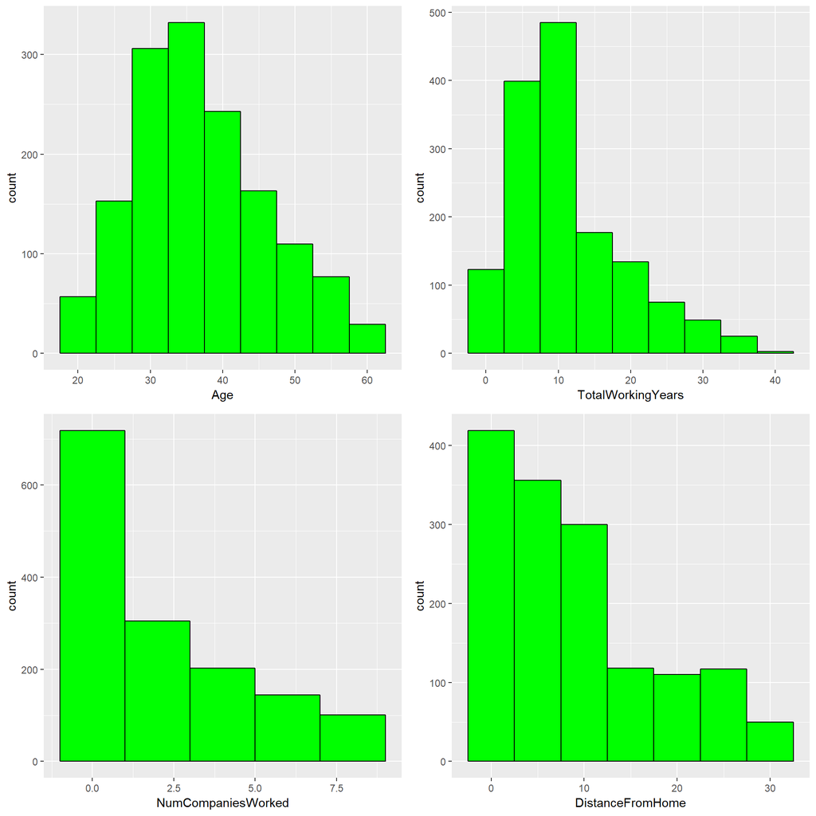

```r
#Look at basic total employee demographics such as Age, Working Years, Companies worked for and Distance from Home
#Age breakdown
p1 = ggplot(empDF) + geom_histogram(aes(Age), binwidth=5, fill="green", col="black")

#Total Working Years
p2 = ggplot(empDF) + geom_histogram(aes(TotalWorkingYears),binwidth=5, fill="green", col="black")

#Number of Companies Worked
p3 = ggplot(empDF) + geom_histogram(aes(NumCompaniesWorked),binwidth=2, fill="green", col="black")

#Distance From Home
p4 = ggplot(empDF) + geom_histogram(aes(DistanceFromHome),binwidth=5, fill="green", col="black")

ggarrange(p1,p2,p3,p4)
```

### Observations

- Age data looks to be normally distributed.
- Total Working Years, Number of Companies Worked For, and Distance From Home are all right skewed. Transformation of this data may be necessary for further analysis

### Employee Demographics - Financial

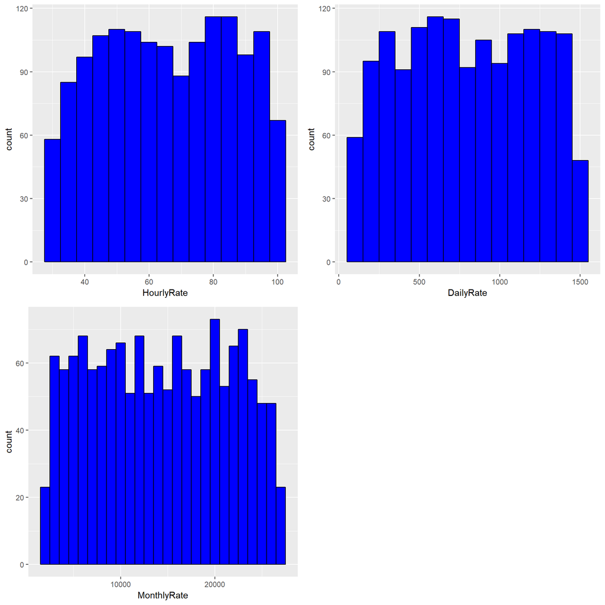

```r
#Look at total employee financial demographics such as DailyRate, HourlyRate, MonthlyRate

#HourlyRate
p1 = ggplot(empDF) + geom_histogram(aes(HourlyRate), binwidth = 5, fill="blue", col="black")

#DailyRate
p2 = ggplot(empDF) + geom_histogram(aes(DailyRate), binwidth = 100, fill="blue", col="black")

#MonthlyRate
p3 = ggplot(empDF) + geom_histogram(aes(MonthlyRate), binwidth = 1000, fill="blue", col="black")

ggarrange(p1,p2,p3)
```

### Observations

- No patterns are observed in this data.

### Employee Demographics - Work Environment

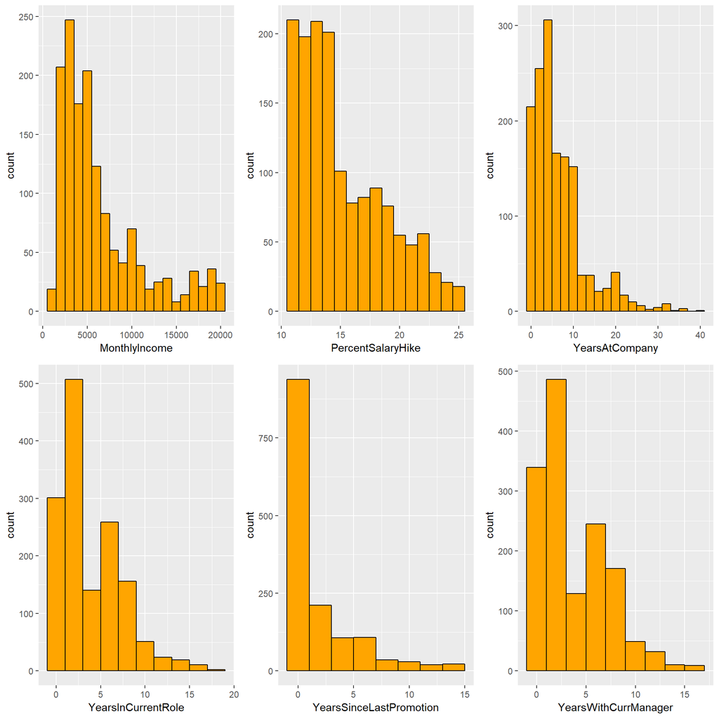

```r
#Look at work environment dempgraphics such as income, years in current role,  time with current manager, years since last promotion
#training time, years at company
#Monthly Income
p1 = ggplot(empDF) + geom_histogram(aes(MonthlyIncome), binwidth = 1000, fill = "orange",col = "black")

#Percent Salary Hike
p2 = ggplot(empDF) + geom_histogram(aes(PercentSalaryHike), binwidth = 1, fill = "orange",col = "black")

#Years At Company
p3 = ggplot(empDF) + geom_histogram(aes(YearsAtCompany), binwidth = 2, fill = "orange",col = "black")

#Years in Current Role
p4 = ggplot(empDF) + geom_histogram(aes(YearsInCurrentRole), binwidth = 2, fill = "orange",col = "black")

#Years Since Last Promotion
p5 = ggplot(empDF) + geom_histogram(aes(YearsSinceLastPromotion), binwidth = 2, fill = "orange",col = "black")

#Years with Current Manager
p6 = ggplot(empDF) + geom_histogram(aes(YearsWithCurrManager), binwidth = 2, fill = "orange",col = "black")

ggarrange(p1,p2,p3,p4,p5,p6)
```

### Observations

- All data for these observations is right skewed. Transformation of data may be needed for further analysis

## Univariate EDA - Categorical Variables

### Employee Demographics - Personal

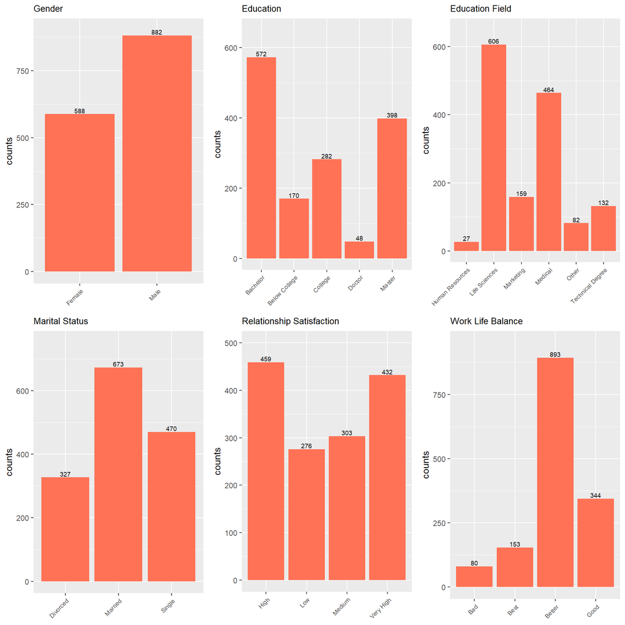

```r
#Investigate personal demographics in the data such as gender, education marital status, etc.
#Gender
p1 = empDF %>%
  group_by(Gender) %>%
  dplyr::summarise(counts = n()) %>%
  ggplot(aes(x = as.factor(Gender), y = counts)) + geom_bar(stat = 'identity', fill = "coral1") + ggtitle("Gender") +geom_text(aes(label=counts), size = 2.5, position=position_dodge(width=0.2), vjust=-0.25) + theme(plot.title = element_text(size =10),axis.text.x = element_text(size =7,angle = 45, hjust = 1),axis.title.x=element_blank()) + scale_y_continuous(limits = c(0, 900))

#Education
p2 = empDF %>%
  group_by(Education) %>%
  dplyr::summarise(counts = n()) %>%
  ggplot(aes(x = as.factor(Education), y = counts)) + geom_bar(stat = 'identity', fill = "coral1") + ggtitle("Education") +geom_text(aes(label=counts), size = 2.5, position=position_dodge(width=0.2), vjust=-0.25) + theme(plot.title = element_text(size =10),axis.text.x = element_text(size =7,angle = 45, hjust = 1),axis.title.x=element_blank()) + scale_y_continuous(limits = c(0, 650))

#Education Field
p3 = empDF %>%
  group_by(EducationField) %>%
 dplyr::summarise(counts = n()) %>%
  ggplot(aes(x = as.factor(EducationField), y = counts)) + geom_bar(stat = 'identity', fill = "coral1") + ggtitle("Education Field") +geom_text(aes(label=counts), size = 2.5, position=position_dodge(width=0.2), vjust=-0.25) + theme(plot.title = element_text(size =10),axis.text.x = element_text(size =7,angle = 45, hjust = 1),axis.title.x=element_blank()) + scale_y_continuous(limits = c(0, 650))

#Marital Status
p4 = empDF %>%
  group_by(MaritalStatus) %>%
  dplyr::summarise(counts = n()) %>%
  ggplot(aes(x = as.factor(MaritalStatus), y = counts)) + geom_bar(stat = 'identity', fill = "coral1")+ ggtitle("Marital Status") +geom_text(aes(label=counts), size = 2.5, position=position_dodge(width=0.2), vjust=-0.25) + theme(plot.title = element_text(size =10),axis.text.x = element_text(size =7,angle = 45, hjust = 1),axis.title.x=element_blank()) + scale_y_continuous(limits = c(0, 750))

#Relationship Satisfaction
p5 = empDF %>%
  group_by(RelationshipSatisfaction) %>%
  dplyr::summarise(counts = n()) %>%
  ggplot(aes(x = as.factor(RelationshipSatisfaction), y = counts)) + geom_bar(stat = 'identity', fill = "coral1") + ggtitle("Relationship Satisfaction") +geom_text(aes(label=counts), size = 2.5, position=position_dodge(width=0.2), vjust=-0.25) + theme(plot.title = element_text(size =10),axis.text.x = element_text(size =7,angle = 45, hjust = 1),axis.title.x=element_blank())+ scale_y_continuous(limits = c(0, 500))

#Work Life Balance
p6 = empDF %>%
  group_by(WorkLifeBalance) %>%
  dplyr::summarise(counts = n()) %>%
  ggplot(aes(x = as.factor(WorkLifeBalance), y = counts)) + geom_bar(stat = 'identity', fill = "coral1")+ ggtitle("Work Life Balance") +geom_text(aes(label=counts), size = 2.5, position=position_dodge(width=0.2), vjust=-0.25) + theme(plot.title = element_text(size =10),axis.text.x = element_text(size =7,angle = 45, hjust = 1),axis.title.x=element_blank()) + scale_y_continuous(limits = c(0, 950))

ggarrange(p1,p2,p3,p4,p5,p6)
```

### Employee Demographics - Work Environment

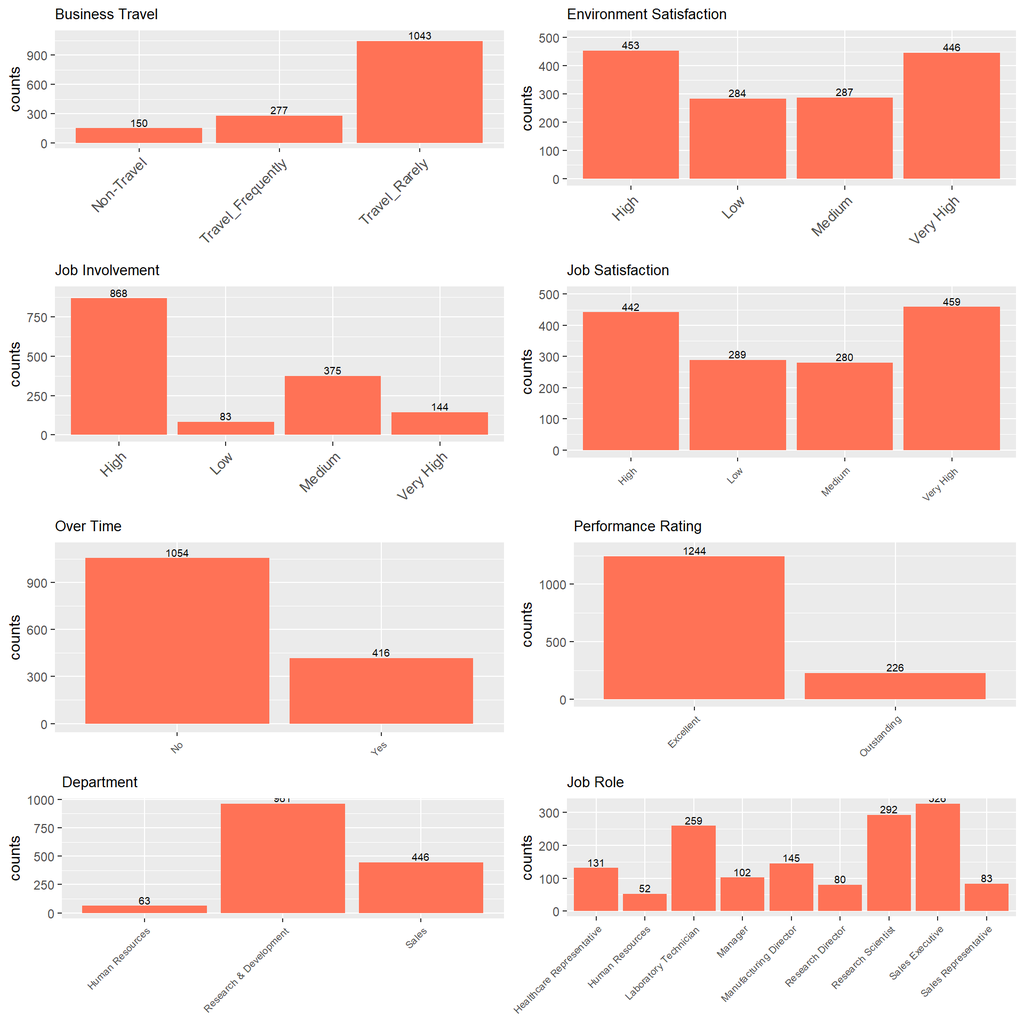

```r
#Investigate work environment categorical variables such as Business Travel, Overtime, etc

#Business Travel
p1 = empDF %>%
  group_by(BusinessTravel) %>%
  dplyr::summarise(counts = n()) %>%
  ggplot(aes(x = as.factor(BusinessTravel), y = counts)) + geom_bar(stat = 'identity', fill = "coral1") + ggtitle("Business Travel") +geom_text(aes(label=counts), size = 2.5, position=position_dodge(width=0.2), vjust=-0.25)+ theme(plot.title = element_text(size =10),axis.text.x = element_text(size =10,angle = 45, hjust = 1),axis.title.x=element_blank())+ scale_y_continuous(limits = c(0, 1100))

#Environmental Satisfaction
p2 = empDF %>%
  group_by(EnvironmentSatisfaction) %>%
  dplyr::summarise(counts = n()) %>%
  ggplot(aes(x = as.factor(EnvironmentSatisfaction), y = counts)) + geom_bar(stat = 'identity', fill = "coral1") + ggtitle("Environment Satisfaction") + geom_text(aes(label=counts), size = 2.5, position=position_dodge(width=0.2), vjust=-0.25) + theme(plot.title = element_text(size =10),axis.text.x = element_text(size =10,angle = 45, hjust = 1),axis.title.x=element_blank()) + scale_y_continuous(limits = c(0, 500))

#Job Involvement
p3 = empDF %>%
  group_by(JobInvolvement) %>%
 dplyr::summarise(counts = n()) %>%
  ggplot(aes(x = as.factor(JobInvolvement), y = counts)) + geom_bar(stat = 'identity', fill = "coral1") + ggtitle("Job Involvement") +geom_text(aes(label=counts), size = 2.5, position=position_dodge(width=0.2), vjust=-0.25)+ theme(plot.title = element_text(size =10),axis.text.x = element_text(size =10,angle = 45, hjust = 1),axis.title.x=element_blank()) + scale_y_continuous(limits = c(0, 900))

#Job Satisfaction
p4 = empDF %>%
  group_by(JobSatisfaction) %>%
  dplyr::summarise(counts = n()) %>%
  ggplot(aes(x = as.factor(JobSatisfaction), y = counts)) + geom_bar(stat = 'identity', fill = "coral1") + ggtitle("Job Satisfaction") +geom_text(aes(label=counts), size = 2.5, position=position_dodge(width=0.2), vjust=-0.25) + theme(plot.title = element_text(size =10),axis.text.x = element_text(size =7,angle = 45, hjust = 1),axis.title.x=element_blank()) + scale_y_continuous(limits = c(0, 500))

#Over Time
p5 = empDF %>%
  group_by(OverTime) %>%
  dplyr::summarise(counts = n()) %>%
  ggplot(aes(x = as.factor(OverTime), y = counts)) + geom_bar(stat = 'identity', fill = "coral1") + ggtitle("Over Time") +geom_text(aes(label=counts), size = 2.5, position=position_dodge(width=0.2), vjust=-0.25)+ theme(plot.title = element_text(size =10),axis.text.x = element_text(size =7,angle = 45, hjust = 1),axis.title.x=element_blank()) + scale_y_continuous(limits = c(0, 1100))

#Performance Rating
p6 = empDF %>%
  group_by(PerformanceRating) %>%
  dplyr::summarise(counts = n()) %>%
  ggplot(aes(x = as.factor(PerformanceRating), y = counts)) + geom_bar(stat = 'identity', fill = "coral1") + ggtitle("Performance Rating") +geom_text(aes(label=counts), size = 2.5, position=position_dodge(width=0.2), vjust=-0.25)+ theme(plot.title = element_text(size =10),axis.text.x = element_text(size =7,angle = 45, hjust = 1),axis.title.x=element_blank()) + scale_y_continuous(limits = c(0, 1300))

#Employee By Department
p7 = empDF %>%
  group_by(Department) %>%
  dplyr::summarise(counts = n()) %>%
  ggplot(aes(x = as.factor(Department), y = counts)) + geom_bar(stat = 'identity', fill = "coral1") + ggtitle("Department") +geom_text(aes(label=counts), size = 2.5, position=position_dodge(width=0.2), vjust=-0.25)+ theme(plot.title = element_text(size =10),axis.text.x = element_text(size = 7, angle = 45, hjust = 1),axis.title.x=element_blank())

#Job Roles
p8 = empDF %>%
  group_by(JobRole) %>%
  dplyr::summarise(counts = n()) %>%
  ggplot(aes(x = as.factor(JobRole), y = counts)) + geom_bar(stat = 'identity', fill = "coral1") + ggtitle("Job Role") +geom_text(aes(label=counts), size = 2.5, position=position_dodge(width=0.2), vjust=-0.25) + theme(plot.title = element_text(size =10),axis.text.x = element_text(size =7,angle = 45, hjust = 1),axis.title.x=element_blank())

ggarrange(p1,p2,p3,p4,p5,p6,p7,p8,ncol=2,nrow=4)
```

# Bivariate EDA

Now start analyzing data in relation to our attrition variable. Since attribution is the target variable we want to see if we uncover any hidden relationships. As before start with the non-categorical (numeric) variables first and then move to the categorical variables.

## Non-Categorical Variables

### Employee Demographics - Basic

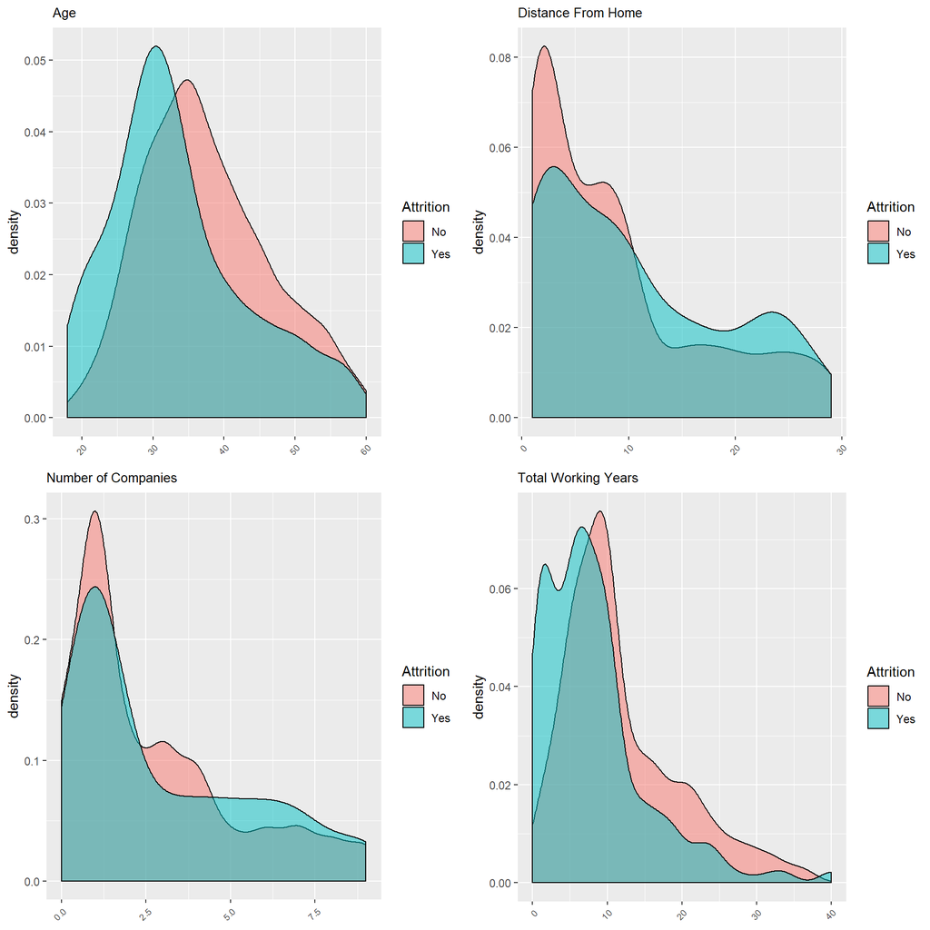

```r
#Evaluate non-categorical variables as they relate to the attrition variable. We'll use density plots with alpha = 0.5
#Age
p1 = empDF %>%
  ggplot(aes(x = Age, fill = Attrition)) + geom_density(alpha = 0.5) + ggtitle("Age") + theme(plot.title = element_text(size =10),axis.text.x = element_text(size =7,angle = 45, hjust = 1),axis.title.x=element_blank())

#Distance from Home
p2 = empDF %>%
  ggplot(aes(x = DistanceFromHome, fill = Attrition)) + geom_density(alpha = 0.5) + ggtitle("Distance From Home")  + theme(plot.title = element_text(size =10),axis.text.x = element_text(size =7,angle = 45, hjust = 1),axis.title.x=element_blank())

#Number of Companies Worked
p3 = empDF %>%
  ggplot(aes(x = NumCompaniesWorked, fill = Attrition)) + geom_density(alpha = 0.5) + ggtitle("Number of Companies")  + theme(plot.title = element_text(size =10),axis.text.x = element_text(size =7,angle = 45, hjust = 1),axis.title.x=element_blank())

#Total Working Years
p4 = empDF %>%
  ggplot(aes(x = TotalWorkingYears, fill = Attrition)) + geom_density(alpha = 0.5) + ggtitle("Total Working Years")  + theme(plot.title = element_text(size =10),axis.text.x = element_text(size =7,angle = 45, hjust = 1),axis.title.x=element_blank())

ggarrange(p1,p2,p3,p4)
```

### Observations

- Younger employees between 25-35 years have a higher attrition rate.
- There is a higher attrition rate when the distance from home is greater than 10. Attrition rate is less below 10.
- Attrition rate seems to be higher for employees who have work with 5 to 7 companies.
- The highest attrition rates seem to be with employees with between 0 to 7 years of work experience.

### Employee Demographics - Financial

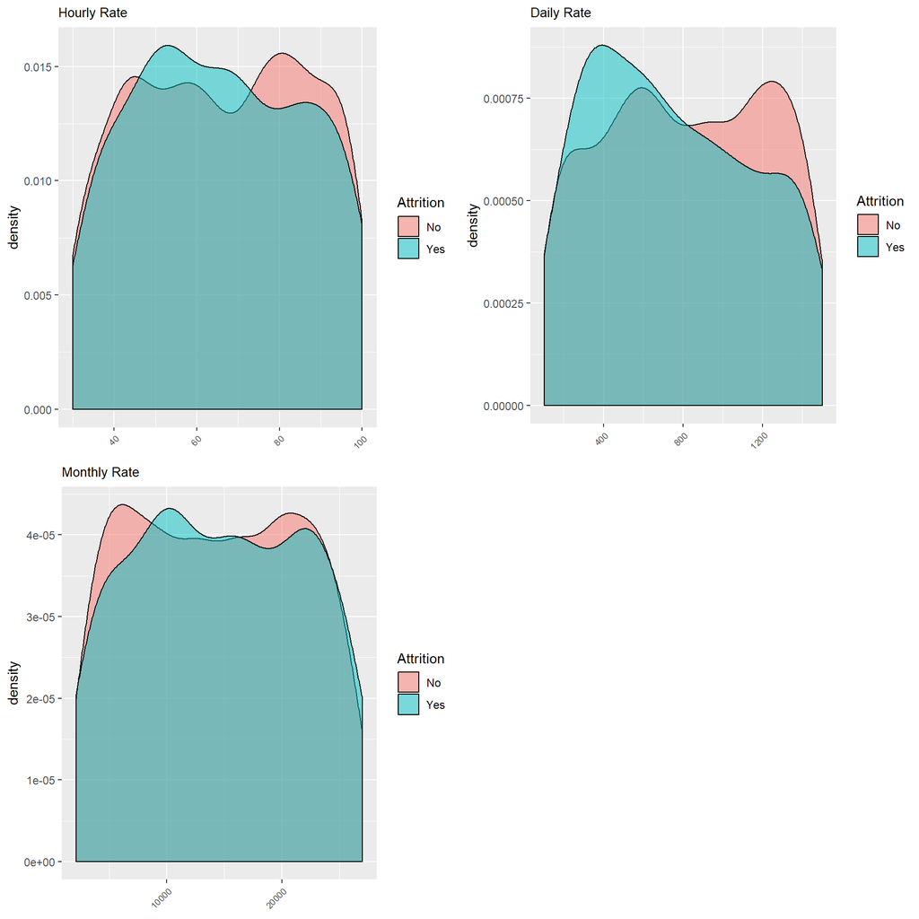

```r
#Evaluate non-categorical variables as they relate to the attrition variable for financial values. We'll use density plots with alpha = 0.5
#Hourly Rate
p1 = empDF %>%
  ggplot(aes(x = HourlyRate, fill = Attrition)) + geom_density(alpha = 0.5) + ggtitle("Hourly Rate") + theme(plot.title = element_text(size =10),axis.text.x = element_text(size =7,angle = 45, hjust = 1),axis.title.x=element_blank())

#Daily Rate
p2 = empDF %>%
  ggplot(aes(x = DailyRate, fill = Attrition)) + geom_density(alpha = 0.5) + ggtitle("Daily Rate") + theme(plot.title = element_text(size =10),axis.text.x = element_text(size =7,angle = 45, hjust = 1),axis.title.x=element_blank())

#Monthly Rate
p3 = empDF %>%
  ggplot(aes(x = MonthlyRate, fill = Attrition)) + geom_density(alpha = 0.5)+ ggtitle("Monthly Rate") + theme(plot.title = element_text(size =10),axis.text.x = element_text(size =7,angle = 45, hjust = 1),axis.title.x=element_blank())

ggarrange(p1,p2,p3)
```

### Observations

- There are no observable patterns in this data.

### Employee Demographics - Work Environment

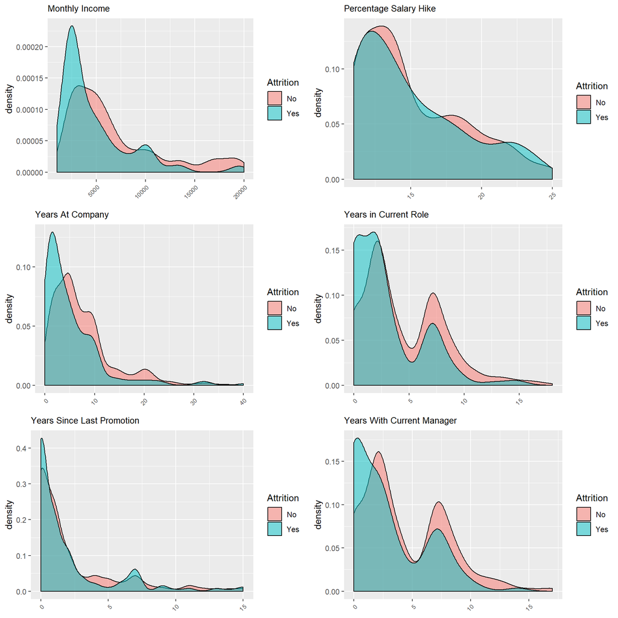

```r
#Evaluate non-categorical variables as they relate to the attrition variable for work environment values. We'll use density plots with alpha = 0.5
#Monthly Income
p1 = empDF %>%
  ggplot(aes(x = MonthlyIncome, fill = Attrition)) + geom_density(alpha = 0.5) + ggtitle("Monthly Income") + theme(plot.title = element_text(size =10),axis.text.x = element_text(size =7,angle = 45, hjust = 1),axis.title.x=element_blank())

#Salary Hike
p2 = empDF %>%
  ggplot(aes(x = PercentSalaryHike, fill = Attrition)) + geom_density(alpha = 0.5) + ggtitle("Percentage Salary Hike") + theme(plot.title = element_text(size =10),axis.text.x = element_text(size =7,angle = 45, hjust = 1),axis.title.x=element_blank())

#Years at Company
p3 = empDF %>%
  ggplot(aes(x = YearsAtCompany, fill = Attrition)) + geom_density(alpha = 0.5) + ggtitle("Years At Company") + theme(plot.title = element_text(size =10),axis.text.x = element_text(size =7,angle = 45, hjust = 1),axis.title.x=element_blank())

#Years In Role
p4 = empDF %>%
  ggplot(aes(x = YearsInCurrentRole, fill = Attrition)) + geom_density(alpha = 0.5) + ggtitle("Years in Current Role") + theme(plot.title = element_text(size =10),axis.text.x = element_text(size =7,angle = 45, hjust = 1),axis.title.x=element_blank())

#Years Since Promotion
p5 = empDF %>%
  ggplot(aes(x = YearsSinceLastPromotion, fill = Attrition)) + geom_density(alpha = 0.5) + ggtitle("Years Since Last Promotion") + theme(plot.title = element_text(size =10),axis.text.x = element_text(size =7,angle = 45, hjust = 1),axis.title.x=element_blank())

#Years with Current Manager
p6 = empDF %>%
  ggplot(aes(x = YearsWithCurrManager, fill = Attrition)) + geom_density(alpha = 0.5) + ggtitle("Years With Current Manager") + theme(plot.title = element_text(size =10),axis.text.x = element_text(size =7,angle = 45, hjust = 1),axis.title.x=element_blank())

ggarrange(p1,p2,p3,p4,p5,p6, ncol=2, nrow=3)
```

## Bivariate EDA - Categorical Variables

### Employee Demographics - Personal

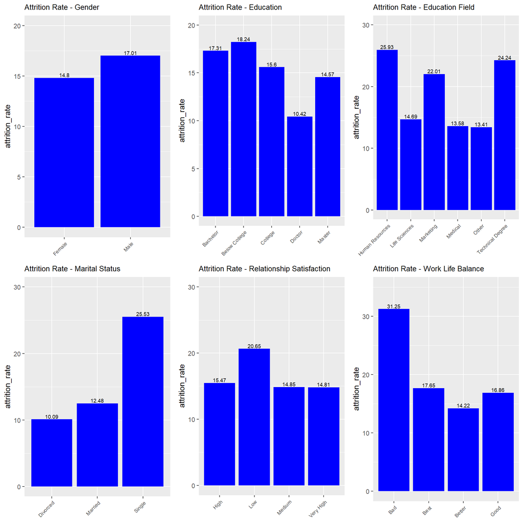

```r
#Investigate categorical variables as they relate to the attrition variable. Focus on the personal variables in this section
#Gender
p1 = empDF %>%
  group_by(Gender) %>%
  dplyr::summarise(attrition_rate = round((sum(if_else(Attrition == "Yes",1,0))/n()*100),2)) %>%
  ggplot(aes(x = Gender, y = attrition_rate))+ geom_bar(stat = 'identity',fill = "blue") + ggtitle("Attrition Rate - Gender") + theme(plot.title = element_text(size =10),axis.text.x = element_text(size =7,angle = 45, hjust = 1),axis.title.x=element_blank()) +geom_text(aes(label=attrition_rate), size = 2.5, position=position_dodge(width=0.2), vjust=-0.25)+ scale_y_continuous(limits = c(0, 20))

#Education
p2 = empDF %>%
  group_by(Education) %>%
  dplyr::summarise(attrition_rate = round((sum(if_else(Attrition == "Yes",1,0))/n()*100),2)) %>%
  ggplot(aes(x = Education, y = attrition_rate))+ geom_bar(stat = 'identity',fill = "blue") + ggtitle("Attrition Rate - Education") + theme(plot.title = element_text(size =10),axis.text.x = element_text(size =7,angle = 45, hjust = 1),axis.title.x=element_blank()) +geom_text(aes(label=attrition_rate), size = 2.5, position=position_dodge(width=0.2), vjust=-0.25)+ scale_y_continuous(limits = c(0, 20))

#Education Field
p3 = empDF %>%
  group_by(EducationField) %>%
  dplyr::summarise(attrition_rate = round((sum(if_else(Attrition == "Yes",1,0))/n()*100),2)) %>%
  ggplot(aes(x = EducationField, y = attrition_rate))+ geom_bar(stat = 'identity',fill = "blue") + ggtitle("Attrition Rate - Education Field") + theme(plot.title = element_text(size =10),axis.text.x = element_text(size =7,angle = 45, hjust = 1),axis.title.x=element_blank()) +geom_text(aes(label=attrition_rate), size = 2.5, position=position_dodge(width=0.2), vjust=-0.25)+ scale_y_continuous(limits = c(0, 30))

#Marital Status
p4 = empDF %>%
  group_by(MaritalStatus) %>%
  dplyr::summarise(attrition_rate = round((sum(if_else(Attrition == "Yes",1,0))/n()*100),2)) %>%
  ggplot(aes(x = MaritalStatus, y = attrition_rate))+ geom_bar(stat = 'identity',fill = "blue") + ggtitle("Attrition Rate - Marital Status") + theme(plot.title = element_text(size =10),axis.text.x = element_text(size =7,angle = 45, hjust = 1),axis.title.x=element_blank()) +geom_text(aes(label=attrition_rate), size = 2.5, position=position_dodge(width=0.2), vjust=-0.25)+ scale_y_continuous(limits = c(0, 30))

#Relationship Satisfaction
p5 = empDF %>%
  group_by(RelationshipSatisfaction) %>%
  dplyr::summarise(attrition_rate = round((sum(if_else(Attrition == "Yes",1,0))/n()*100),2)) %>%
  ggplot(aes(x = as.factor(RelationshipSatisfaction), y = attrition_rate))+ geom_bar(stat = 'identity',fill = "blue") + ggtitle("Attrition Rate - Relationship Satisfaction") + theme(plot.title = element_text(size =10),axis.text.x = element_text(size =7,angle = 45, hjust = 1),axis.title.x=element_blank()) +geom_text(aes(label=attrition_rate), size = 2.5, position=position_dodge(width=0.2), vjust=-0.25)+ scale_y_continuous(limits = c(0, 30))

#Work Life Balance
p6 = empDF %>%
  group_by(WorkLifeBalance) %>%
  dplyr::summarise(attrition_rate = round((sum(if_else(Attrition == "Yes",1,0))/n()*100),2)) %>%
  ggplot(aes(x = as.factor(WorkLifeBalance), y = attrition_rate))+ geom_bar(stat = 'identity',fill = "blue") + ggtitle("Attrition Rate - Work Life Balance") + theme(plot.title = element_text(size =10),axis.text.x = element_text(size =7,angle = 45, hjust = 1),axis.title.x=element_blank()) +geom_text(aes(label=attrition_rate), size = 2.5, position=position_dodge(width=0.2), vjust=-0.25)+ scale_y_continuous(limits = c(0, 35))

ggarrange(p1,p2,p3,p4,p5,p6)
```

### Observations

- Male attrition rate is higher than female attrition rate.
- Attrition rate is approximately 18% for employees with no college education.
- Attrition rate is highest for those employees with backgrounds in HR, Marketing or a Technical Degree.
- Attrition rate is highest for single employees
- Attrition rate is highest for employees with low relationship satisfaction
- Attrition rate is highest for employees with bad work like balance

### Employee Demographics - Work Environment

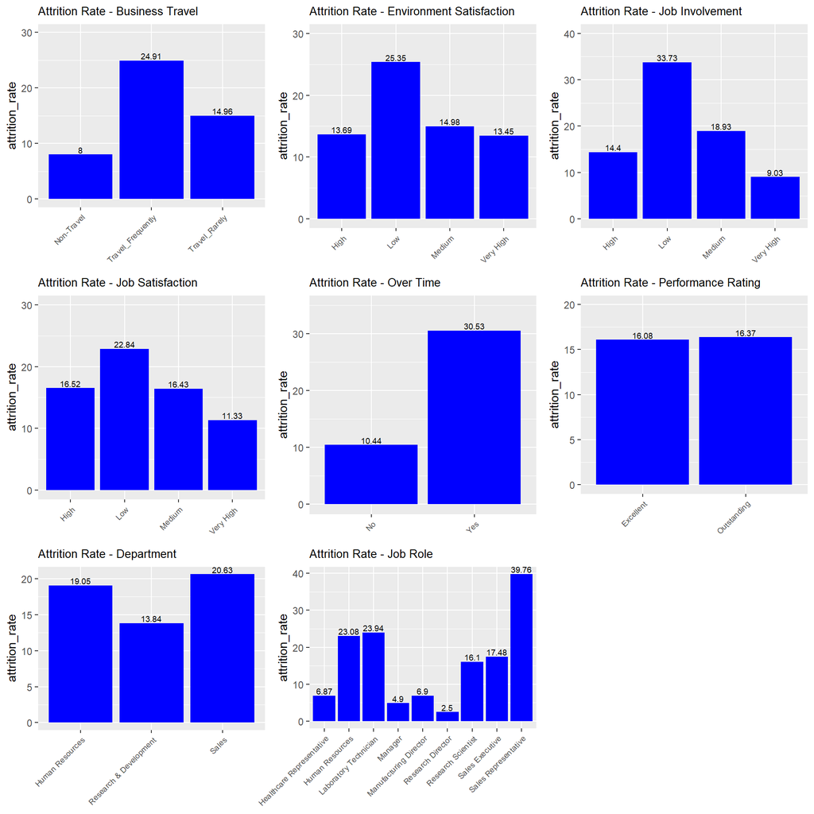

```r
#Investigate work environment categorical variables such as Business Travel, Overtime, etc as they relate to attrition
#Business Travel
p1 = empDF %>%
  group_by(BusinessTravel) %>%
  dplyr::summarise(attrition_rate = round((sum(if_else(Attrition == "Yes",1,0))/n()*100),2)) %>%
  ggplot(aes(x = BusinessTravel, y = attrition_rate))+ geom_bar(stat = 'identity',fill = "blue") + ggtitle("Attrition Rate - Business Travel") + theme(plot.title = element_text(size =10),axis.text.x = element_text(size =7,angle = 45, hjust = 1),axis.title.x=element_blank()) +geom_text(aes(label=attrition_rate), size = 2.5, position=position_dodge(width=0.2), vjust=-0.25)+ scale_y_continuous(limits = c(0, 30))

#Environment Satisfaction
p2 = empDF %>%
  group_by(EnvironmentSatisfaction) %>%
  dplyr::summarise(attrition_rate = round((sum(if_else(Attrition == "Yes",1,0))/n()*100),2)) %>%
  ggplot(aes(x = EnvironmentSatisfaction, y = attrition_rate))+ geom_bar(stat = 'identity',fill = "blue") + ggtitle("Attrition Rate - Environment Satisfaction") + theme(plot.title = element_text(size =10),axis.text.x = element_text(size =7,angle = 45, hjust = 1),axis.title.x=element_blank()) +geom_text(aes(label=attrition_rate), size = 2.5, position=position_dodge(width=0.2), vjust=-0.25)+ scale_y_continuous(limits = c(0, 30))

#Job Involvement
p3 = empDF %>%
  group_by(JobInvolvement) %>%
  dplyr::summarise(attrition_rate = round((sum(if_else(Attrition == "Yes",1,0))/n()*100),2)) %>%
  ggplot(aes(x = JobInvolvement, y = attrition_rate))+ geom_bar(stat = 'identity',fill = "blue") + ggtitle("Attrition Rate - Job Involvement") + theme(plot.title = element_text(size =10),axis.text.x = element_text(size =7,angle = 45, hjust = 1),axis.title.x=element_blank()) +geom_text(aes(label=attrition_rate), size = 2.5, position=position_dodge(width=0.2), vjust=-0.25)+ scale_y_continuous(limits = c(0, 40))

#Job Satisfaction
p4 = empDF %>%
  group_by(JobSatisfaction) %>%
  dplyr::summarise(attrition_rate = round((sum(if_else(Attrition == "Yes",1,0))/n()*100),2)) %>%
  ggplot(aes(x = JobSatisfaction, y = attrition_rate))+ geom_bar(stat = 'identity',fill = "blue") + ggtitle("Attrition Rate - Job Satisfaction") + theme(plot.title = element_text(size =10),axis.text.x = element_text(size =7,angle = 45, hjust = 1),axis.title.x=element_blank()) +geom_text(aes(label=attrition_rate), size = 2.5, position=position_dodge(width=0.2), vjust=-0.25)+ scale_y_continuous(limits = c(0, 30))

#Overtime
p5 = empDF %>%
  group_by(OverTime) %>%
  dplyr::summarise(attrition_rate = round((sum(if_else(Attrition == "Yes",1,0))/n()*100),2)) %>%
  ggplot(aes(x = OverTime, y = attrition_rate))+ geom_bar(stat = 'identity',fill = "blue") + ggtitle("Attrition Rate - Over Time") + theme(plot.title = element_text(size =10),axis.text.x = element_text(size =7,angle = 45, hjust = 1),axis.title.x=element_blank()) +geom_text(aes(label=attrition_rate), size = 2.5, position=position_dodge(width=0.2), vjust=-0.25)+ scale_y_continuous(limits = c(0, 35))

#Performance Rating
p6 = empDF %>%
  group_by(PerformanceRating) %>%
  dplyr::summarise(attrition_rate = round((sum(if_else(Attrition == "Yes",1,0))/n()*100),2)) %>%
  ggplot(aes(x = as.factor(PerformanceRating), y = attrition_rate))+ geom_bar(stat = 'identity',fill = "blue") + ggtitle("Attrition Rate - Performance Rating") + theme(plot.title = element_text(size =10),axis.text.x = element_text(size =7,angle = 45, hjust = 1),axis.title.x=element_blank()) +geom_text(aes(label=attrition_rate), size = 2.5, position=position_dodge(width=0.2), vjust=-0.25)+ scale_y_continuous(limits = c(0, 20))

#Department
p7 = empDF %>%
  group_by(Department) %>%
  dplyr::summarise(attrition_rate = round((sum(if_else(Attrition == "Yes",1,0))/n()*100),2)) %>%
  ggplot(aes(x = Department, y = attrition_rate))+ geom_bar(stat = 'identity',fill = "blue") + ggtitle("Attrition Rate - Department") + theme(plot.title = element_text(size =10),axis.text.x = element_text(size =7,angle = 45, hjust = 1),axis.title.x=element_blank()) +geom_text(aes(label=attrition_rate), size = 2.5, position=position_dodge(width=0.2), vjust=-0.25)

#Job Role
p8 = empDF %>%
  group_by(JobRole) %>%
  dplyr::summarise(attrition_rate = round((sum(if_else(Attrition == "Yes",1,0))/n()*100),2)) %>%
  ggplot(aes(x = JobRole, y = attrition_rate))+ geom_bar(stat = 'identity',fill = "blue") + ggtitle("Attrition Rate - Job Role") + theme(plot.title = element_text(size =10),axis.text.x = element_text(size =7,angle = 45, hjust = 1),axis.title.x=element_blank()) +geom_text(aes(label=attrition_rate), size = 2.5, position=position_dodge(width=0.2), vjust=-0.25)

ggarrange(p1,p2,p3,p4,p5,p6,p7,p8)
```

### Observations

- Employees who travel frequently have a higher attrition rate.
- Employees who score environmental satisfaction, job involvement and job satisfaction low have higher attrition.
- Employees who work overtime have a higher attrition rate (approximately 30%).
- Employees in the Sales Department have the highest attrition rate at 20%.
- Employees who are Sales Representatives have the highest attrition rate at 40%.

# Correlation

Now that we’ve looked at the variables in depth, let’s see what correlations we can find in the data. Break the data up into non-categorical and categorical variables just as before Credit to David Josephs - TA for DS6306 for code for the correlator function and guidance on how best to approach looking at correlation

## Non-Categorical Correlations

For Non-Categorical (numeric) variables we’ll use a heatmap with correlation coefficients

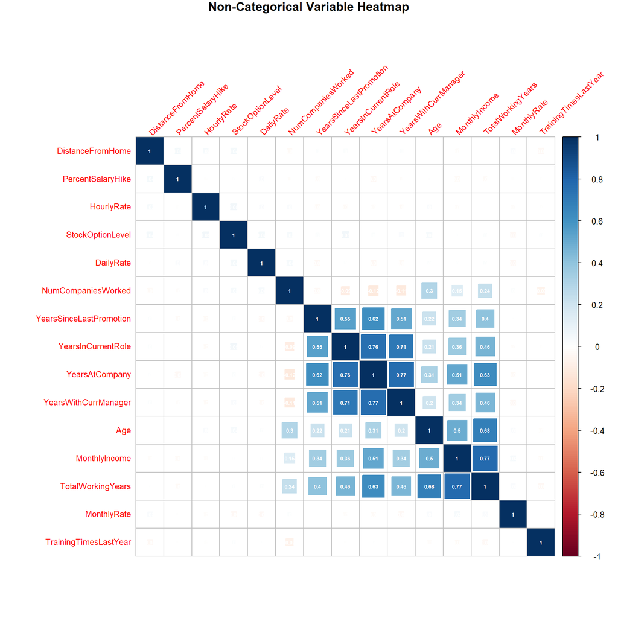

```r
#Credit to David Joesphs for the function to create the correlation plot.
correlator  <-  function(df, title){

    df %>%

        keep(is.numeric) %>%

        tidyr::drop_na() %>%

        cor %>%

        corrplot( addCoef.col = "white", number.digits = 2,

             number.cex = 0.5, method="square",

             order="hclust", title=title,

             tl.srt=45, tl.cex = 0.8, mar=c(0,0,1,0))

}


correlator(empDF, "Non-Categorical Variable Heatmap")
```

### Observations

- YearsInCurrentRole and YearsAtCompany are highly correlated (0.76)
- YearsInCurrentRole and YearsWithCurrManager are highly correlated (0.71)
- YearsAtCompany and YearsInCurrentRole are highly correlated (0.76)
- YearsAtCompany and YearsWithCurrManager are highly correlated (0.77)
- YearsAtCompany and TotalWorkingYears are highly correlated (0.63)
- Age and TotalWorkingYears are highly correlated (0.68)
- MonthyIncome and TotalWorkingYears are highly correlated (0.77)

# Conclusion

From the analysis above we can see that the following variables may have an influence on attrition:

- Department
- Job Role
- Level of Education
- Amount of Travel
- Amount of Overtime
- Employees with low satisfaction scores in Job Satisfaction, Job Engagement and Environmental conditions may also need to be taken into account.